# Introdución a R Markdown

D. S. Fernández del Viso

2024-12-15

### **Guía rápida para usar R Markdown**

R Markdown es una herramienta poderosa para combinar texto, código R y resultados en un único documento. Aquí tienes una guía básica para empezar:

### **1. ¿Qué es R Markdown?**

- Es un formato que permite integrar texto (en Markdown) y código R.
- Puedes generar documentos en varios formatos como HTML, PDF, Word o PowerPoint.

### **2. Cómo crear un archivo R Markdown**

1. Abre RStudio.
2. Ve a **File > New File > R Markdown**.
3. Completa el título, autor y formato de salida (HTML, PDF o Word).
4. Haz clic en “OK” y RStudio generará una plantilla básica.

### **3. Estructura básica de un archivo R Markdown**

Un archivo R Markdown tiene tres partes principales:

#### **a. Cabecera YAML**

Define el título, autor, fecha y formato de salida del documento.

```yaml
---
title: "Mi Primer Documento en R Markdown"
author: "Tu Nombre"
date: "2024-12-15
output: html_document
---
```

#### **b. Texto en Markdown**

Usa sintaxis Markdown para escribir texto. Ejemplo:

```markdown
# Título principal
## Subtítulo
**Texto en negrita**
*Cursiva*
1. Listas numeradas
- Listas con viñetas
[Enlace](https://www.rstudio.com)
![Imagen](imagen.png)
```

#### **c. Bloques de código R**

Inserta código R entre

**```{r}**  
y  
**```**

Puedes usar el ícono de **+C** (verde) en RStudio para insertar un bloque de código.

```r
# Código R
x <- 1:10
mean(x)
```

```
## [1] 5.5
```

### **4. Insertar código en R Markdown**

#### **a. Bloques de código**

Usa bloques de código para ejecutar R:

```r
# Código R
summary(cars)
```

```
##      speed           dist
##  Min.   : 4.0   Min.   :  2.00
##  1st Qu.:12.0   1st Qu.: 26.00
##  Median :15.0   Median : 36.00
##  Mean   :15.4   Mean   : 42.98
##  3rd Qu.:19.0   3rd Qu.: 56.00
##  Max.   :25.0   Max.   :120.00
```

- **Opciones comunes para los chunks:**
  - `echo=TRUE`: Muestra el código en el documento (por defecto).
  - `echo=FALSE`: Oculta el código pero muestra los resultados.
  - `eval=FALSE`: No ejecuta el código.
  - `include=FALSE`: No muestra ni el código ni los resultados.

#### **b. Código en línea**

Incluye resultados de código directamente en el texto con *r resultado* entre `.

```markdown
El promedio de 1 a 10 es 5.5.
```

### **5. Generar el documento**

1. Haz clic en el botón **Knit** en la barra superior de RStudio.
2. Selecciona el formato de salida (HTML, PDF o Word).
3. El documento generado se abrirá automáticamente.

### **6. Ejemplo completo**

```yaml
---
title: "Análisis de Datos"
author: "Tu Nombre"
date: "2024-12-15"
output: html_document
---
```

````markdown
# Introducción
Este documento muestra un análisis básico de datos en R.

## Cargar datos

```r
data(mtcars)
head(mtcars)
````

```
##                    mpg cyl disp  hp drat    wt  qsec vs am gear carb
## Mazda RX4         21.0   6  160 110 3.90 2.620 16.46  0  1    4    4
## Mazda RX4 Wag     21.0   6  160 110 3.90 2.875 17.02  0  1    4    4
## Datsun 710        22.8   4  108  93 3.85 2.320 18.61  1  1    4    1
## Hornet 4 Drive    21.4   6  258 110 3.08 3.215 19.44  1  0    3    1
## Hornet Sportabout 18.7   8  360 175 3.15 3.440 17.02  0  0    3    2
## Valiant           18.1   6  225 105 2.76 3.460 20.22  1  0    3    1
```

## Resumen de datos

El conjunto de datos tiene 32 filas y 11 columnas.

```r
summary(mtcars)
```

```
##       mpg             cyl             disp             hp
##  Min.   :10.40   Min.   :4.000   Min.   : 71.1   Min.   : 52.0
##  1st Qu.:15.43   1st Qu.:4.000   1st Qu.:120.8   1st Qu.: 96.5
##  Median :19.20   Median :6.000   Median :196.3   Median :123.0
##  Mean   :20.09   Mean   :6.188   Mean   :230.7   Mean   :146.7
##  3rd Qu.:22.80   3rd Qu.:8.000   3rd Qu.:326.0   3rd Qu.:180.0
##  Max.   :33.90   Max.   :8.000   Max.   :472.0   Max.   :335.0
##       drat             wt             qsec             vs
##  Min.   :2.760   Min.   :1.513   Min.   :14.50   Min.   :0.0000
##  1st Qu.:3.080   1st Qu.:2.581   1st Qu.:16.89   1st Qu.:0.0000
##  Median :3.695   Median :3.325   Median :17.71   Median :0.0000
##  Mean   :3.597   Mean   :3.217   Mean   :17.85   Mean   :0.4375
##  3rd Qu.:3.920   3rd Qu.:3.610   3rd Qu.:18.90   3rd Qu.:1.0000
##  Max.   :4.930   Max.   :5.424   Max.   :22.90   Max.   :1.0000
##        am              gear            carb
##  Min.   :0.0000   Min.   :3.000   Min.   :1.000
##  1st Qu.:0.0000   1st Qu.:3.000   1st Qu.:2.000
##  Median :0.0000   Median :4.000   Median :2.000
##  Mean   :0.4062   Mean   :3.688   Mean   :2.812
##  3rd Qu.:1.0000   3rd Qu.:4.000   3rd Qu.:4.000
##  Max.   :1.0000   Max.   :5.000   Max.   :8.000
```

## Gráfica

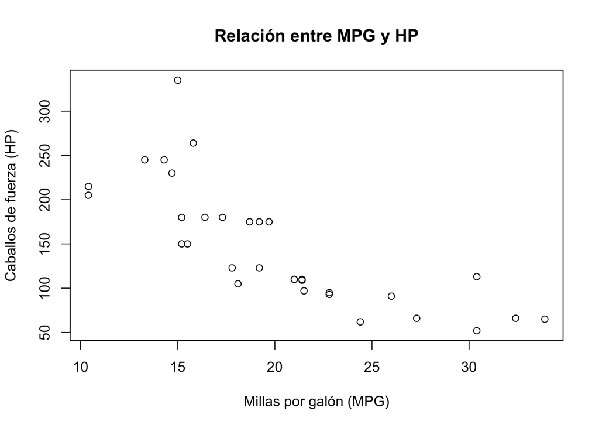

[output not shown]